# MTH6139 Time Series

Analyse CO2 Emission Throughout the Years Coursework 1

Dayana Batrisyia Binti Azizan(210926200)

16 March 2024

The purpose of this project is to analyse the long term patterns of CO2 emission throughout 1959s to 1997. Here, we will use some co2 after we run two packages, which are prophet and remote. Why do we use co2? co2 is the built-in dataset that is in R, which shows the CO2 concentration in atmosphere, in parts per million(ppm). If you run ‘?co2’ in R console, it will shows information of co2 dataset.

## The Usage of Prophet in Our Analysation

We use Prophet in this analysation because it is easy to use even for people without time series background to navigate! So don’t forgot to install and use your ‘prophet’ package!

## Plot of Carbon Emission in Atmosphere in par million(ppm)

When you run the codes below, you will see a plot of Year(ds) and Carbon Emission in Atmosphere in par million(ppm)(y).

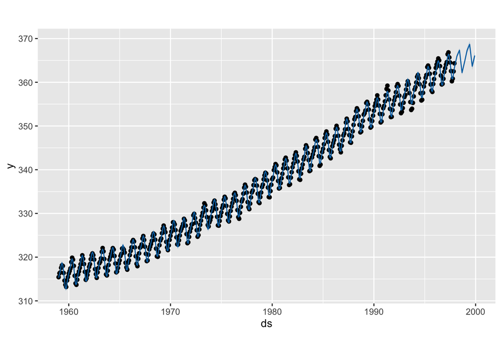

```r
co2.df = data.frame(
  ds=zoo::as.yearmon(time(co2)),
  y=co2)
m = prophet::prophet(co2.df, weekly.seasonality = TRUE, daily.seasonality = TRUE)
f = prophet::make_future_dataframe(m, periods=8, freq="quarter")
p = predict(m, f)
plot(m,p)
```

## Regression

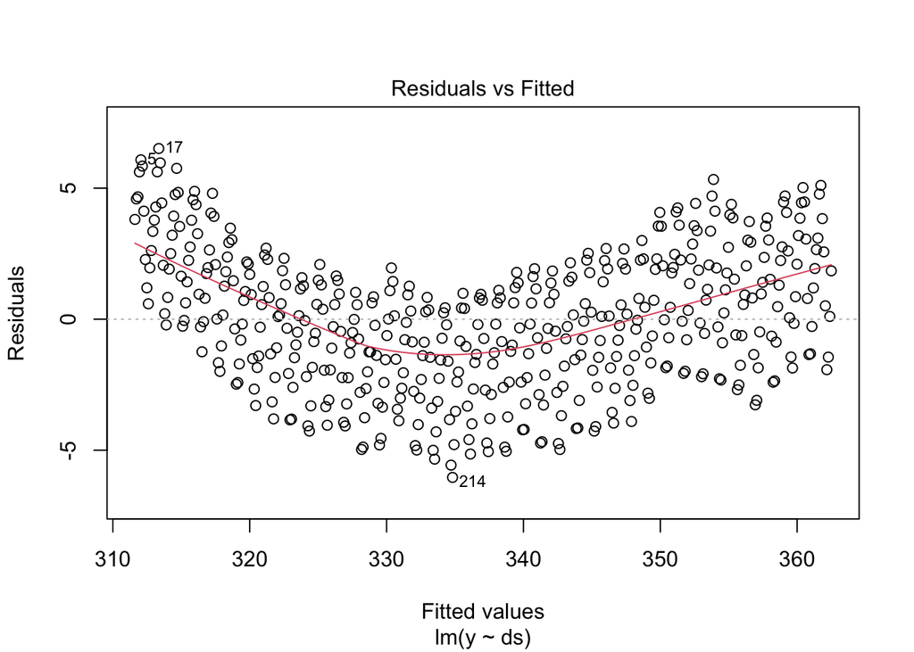

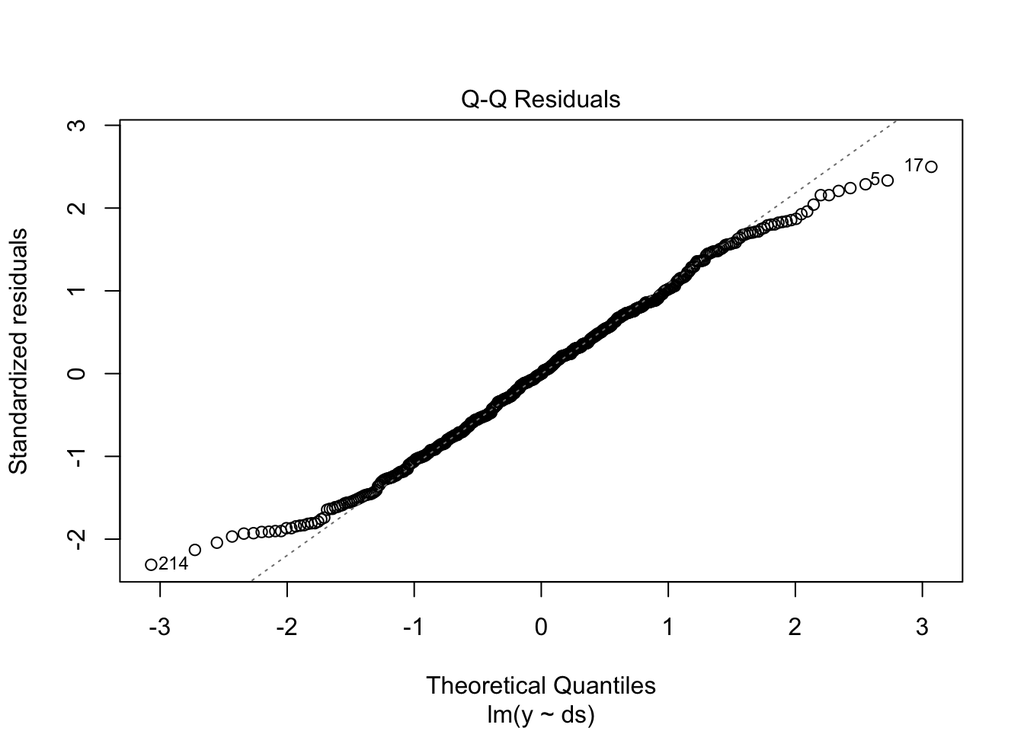

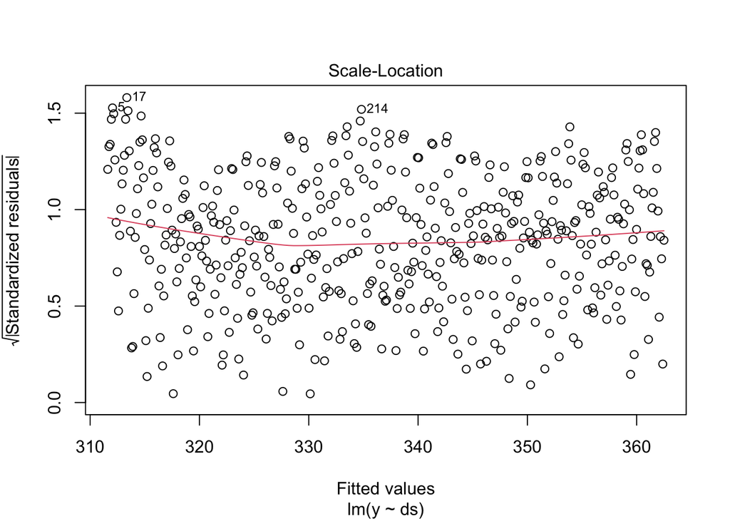

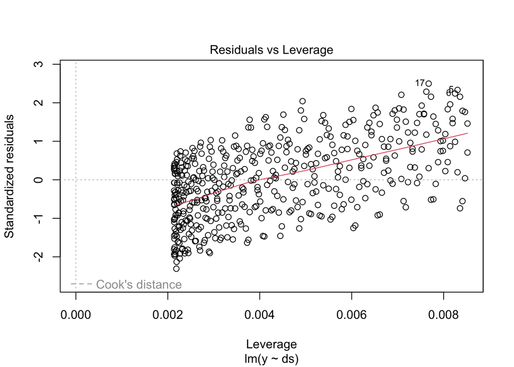

```r
lm_model <- lm(y ~ ds, data = co2.df)
plot(lm_model)
```